# Objective:- In this project we chose the California Housing Prices dataset from the StatLib repository2

The dataset was based on data from the 1990 California census.

# Import Libraries

by importing libraries it will help to run codes without any error

```python
# Common imports
import pandas as pd
import numpy as np

# data visualization
import matplotlib.pyplot as plt
from sklearn.model_selection import train_test_split

# random seed to make output stable across runs
np.random.seed(42)
```

# **California housing Dataset**

### Get the data: • In this step we work on the following:

• Download the Data • Load the data • Take a Quick Look at the Data Structure • Using DataFrame info() method • Using DataFrame value_counts() method • Using DataFrame describe() method • Plot a Histogram • Create a Test Set

```python
import os
import tarfile
from six.moves import urllib

root = "https://raw.githubusercontent.com/ageron/handson-ml/master/"
path = os.path.join("datasets", "housing")
source = root + "datasets/housing/housing.tgz"

def fetch_housing_data(housing_url=source, path=path):
    if not os.path.isdir(path):
        os.makedirs(path)
    tgz_path = os.path.join(path, "housing.tgz")
    urllib.request.urlretrieve(housing_url, tgz_path)
    housing_tgz = tarfile.open(tgz_path)
    housing_tgz.extractall(path=path)
    housing_tgz.close()
```

```python
fetch_housing_data()
```

```python
import pandas as pd

def load_data(housing_path=path):
    csv = os.path.join(housing_path, "housing.csv")
    return pd.read_csv(csv)
```

# Load the data and Take a big picture of the data

```python
housing = load_data()
housing.head()
```

|  | longitude | latitude | housing_median_age | total_rooms | total_bedrooms | population | households | median_income | median_house_value | ocean_proximity |
| --- | --- | --- | --- | --- | --- | --- | --- | --- | --- | --- |
| 0 | -122.23 | 37.88 | 41.0 | 880.0 | 129.0 | 322.0 | 126.0 | 8.3252 | 452600.0 | NEAR BAY |
| 1 | -122.22 | 37.86 | 21.0 | 7099.0 | 1106.0 | 2401.0 | 1138.0 | 8.3014 | 358500.0 | NEAR BAY |
| 2 | -122.24 | 37.85 | 52.0 | 1467.0 | 190.0 | 496.0 | 177.0 | 7.2574 | 352100.0 | NEAR BAY |
| 3 | -122.25 | 37.85 | 52.0 | 1274.0 | 235.0 | 558.0 | 219.0 | 5.6431 | 341300.0 | NEAR BAY |
| 4 | -122.25 | 37.85 | 52.0 | 1627.0 | 280.0 | 565.0 | 259.0 | 3.8462 | 342200.0 | NEAR BAY |

Each row represents one district. The dataset has 10 attributes: longitude, latitude, housing_median_age, total_rooms, total_bedrooms, population, households, median_income, median_house_value and ocean_proximity.

```python
housing.info()
```

```
<class 'pandas.core.frame.DataFrame'>
RangeIndex: 20640 entries, 0 to 20639
Data columns (total 10 columns):
 #   Column              Non-Null Count  Dtype
---  ------              --------------  -----
 0   longitude           20640 non-null  float64
 1   latitude            20640 non-null  float64
 2   housing_median_age  20640 non-null  float64
 3   total_rooms         20640 non-null  float64
 4   total_bedrooms      20433 non-null  float64
 5   population          20640 non-null  float64
 6   households          20640 non-null  float64
 7   median_income       20640 non-null  float64
 8   median_house_value  20640 non-null  float64
 9   ocean_proximity     20640 non-null  object
dtypes: float64(9), object(1)
memory usage: 1.6+ MB
```

Now we can see a brief description of the data using the "info()" method above.

```python
housing["ocean_proximity"].value_counts()
```

```
ocean_proximity
<1H OCEAN     9136
INLAND        6551
NEAR OCEAN    2658
NEAR BAY      2290
ISLAND           5
Name: count, dtype: int64
```

Now I will use the "describe()" method to show a summary of the numerical attributes:

```python
housing.describe() #summary of the numerical attributes
```

|  | longitude | latitude | housing_median_age | total_rooms | total_bedrooms | population | households | median_income | median_house_value |
| --- | --- | --- | --- | --- | --- | --- | --- | --- | --- |
| count | 20640.000000 | 20640.000000 | 20640.000000 | 20640.000000 | 20433.000000 | 20640.000000 | 20640.000000 | 20640.000000 | 20640.000000 |
| mean | -119.569704 | 35.631861 | 28.639486 | 2635.763081 | 537.870553 | 1425.476744 | 499.539680 | 3.870671 | 206855.816909 |
| std | 2.003532 | 2.135952 | 12.585558 | 2181.615252 | 421.385070 | 1132.462122 | 382.329753 | 1.899822 | 115395.615874 |
| min | -124.350000 | 32.540000 | 1.000000 | 2.000000 | 1.000000 | 3.000000 | 1.000000 | 0.499900 | 14999.000000 |
| 25% | -121.800000 | 33.930000 | 18.000000 | 1447.750000 | 296.000000 | 787.000000 | 280.000000 | 2.563400 | 119600.000000 |
| 50% | -118.490000 | 34.260000 | 29.000000 | 2127.000000 | 435.000000 | 1166.000000 | 409.000000 | 3.534800 | 179700.000000 |
| 75% | -118.010000 | 37.710000 | 37.000000 | 3148.000000 | 647.000000 | 1725.000000 | 605.000000 | 4.743250 | 264725.000000 |
| max | -114.310000 | 41.950000 | 52.000000 | 39320.000000 | 6445.000000 | 35682.000000 | 6082.000000 | 15.000100 | 500001.000000 |

The 25%, 50%, 75% are the percentiles. For an example 75% of the districts have housing_median_age of lower than 37 while 50% are lower than 29 and 25% are lower than 18. These are often called the 25th percentile (or 1st quartile), the median and the 75th percentile (or 3rd quartile).

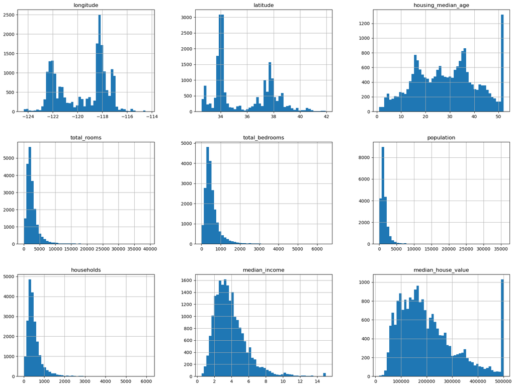

```python
import matplotlib.pyplot as plt
housing.hist(bins=50, figsize=(20, 15))
plt.show()
```

# Train/Test Split

• You have only taken a quick glance at the data, and surely you should learn a whole lot more about it before you decide what algorithms to use, right?

• This is true, but your brain is an amazing pattern detection system, which means that it is highly prone to overfitting: if you look at the test set, you may stumble upon some seemingly interesting pattern in the test data that leads you to select a particular kind of Machine Learning model.

• When you estimate the generalization error using the test set, your estimate will be too optimistic and you will launch a system that will not perform as well as expected. This is called data snooping bias.

• Creating a test set is theoretically quite simple: just pick some instances randomly, typically 20% of the dataset, and set them aside:

```python
import numpy as np
def splitTrainTest(data, testRatio):
 shuffledIndices = np.random.permutation(len(data))
 testSetSize = int(len(data) * testRatio)
 testIndices = shuffledIndices[:testSetSize]
 trainIndices = shuffledIndices[testSetSize:]
 return data.iloc[trainIndices], data.iloc[testIndices]
```

```python
#We will use the straight forward "train_test_split()" method from sklearn to split our data into train and test subsets.
from sklearn.model_selection import train_test_split
train_set, test_set = train_test_split(housing, test_size=0.2, random_state=42)
print(len(train_set), "Train Instances +", len(test_set), "Test Instances")
```

```
16512 Train Instances + 4128 Test Instances
```

The following code creates an income category attribute by dividing the median income by 1.5 (to limit the number of income categories) and rounding up using ceil (to have discrete categories), and then merging all the categories greater than 5 into category 5.

```python
housing["income_cat"] = np.ceil(housing["median_income"] / 1.5)
housing["income_cat"].where(housing["income_cat"] < 5, 5.0, inplace=True)
```

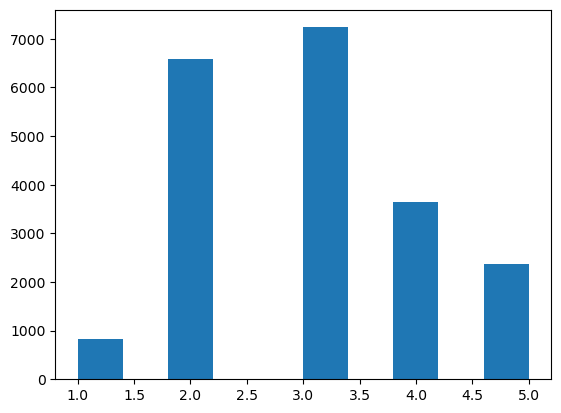

```python
plt.hist(housing["income_cat"])
fig = plt.gcf()
```

Most median income values are clustered around 2–5 (tens of thousands of dollars), but some median incomes go far beyond 6.

It is important to have a sufficient number of instances in your dataset for each stratum, or else the estimate of the stratum’s importance may be biased.

This means that you should not have too many strata, and each stratum should be large enough.

### Now you are ready to do stratified sampling based on the income category. For this you can use

Scikit-Learn’s StratifiedShuffleSplit class:

```python
from sklearn.model_selection import StratifiedShuffleSplit
split = StratifiedShuffleSplit(n_splits=1, test_size=0.2, random_state=42)
for trainIndex, testIndex in split.split(housing, housing["income_cat"]):
    strat_train_set = housing.loc[trainIndex]
    strat_test_set = housing.loc[testIndex]
```

Let’s see if this worked as expected. You can start by looking at the income category proportions in the full housing dataset:

```python
housing["income_cat"].value_counts() / len(housing)
```

```
income_cat
3.0    0.350581
2.0    0.318847
4.0    0.176308
5.0    0.114438
1.0    0.039826
Name: count, dtype: float64
```

```python
strat_train_set.info()
```

```
<class 'pandas.core.frame.DataFrame'>
Index: 16512 entries, 12655 to 19773
Data columns (total 11 columns):
 #   Column              Non-Null Count  Dtype
---  ------              --------------  -----
 0   longitude           16512 non-null  float64
 1   latitude            16512 non-null  float64
 2   housing_median_age  16512 non-null  float64
 3   total_rooms         16512 non-null  float64
 4   total_bedrooms      16354 non-null  float64
 5   population          16512 non-null  float64
 6   households          16512 non-null  float64
 7   median_income       16512 non-null  float64
 8   median_house_value  16512 non-null  float64
 9   ocean_proximity     16512 non-null  object
 10  income_cat          16512 non-null  float64
dtypes: float64(10), object(1)
memory usage: 1.5+ MB
```

```python
strat_test_set.info()
```

```
<class 'pandas.core.frame.DataFrame'>
Index: 4128 entries, 5241 to 3965
Data columns (total 11 columns):
 #   Column              Non-Null Count  Dtype
---  ------              --------------  -----
 0   longitude           4128 non-null   float64
 1   latitude            4128 non-null   float64
 2   housing_median_age  4128 non-null   float64
 3   total_rooms         4128 non-null   float64
 4   total_bedrooms      4079 non-null   float64
 5   population          4128 non-null   float64
 6   households          4128 non-null   float64
 7   median_income       4128 non-null   float64
 8   median_house_value  4128 non-null   float64
 9   ocean_proximity     4128 non-null   object
 10  income_cat          4128 non-null   float64
dtypes: float64(10), object(1)
memory usage: 387.0+ KB
```

```python
# Now we want to remove the income_categoreis attribute because we don't need it anymore.
for set in (strat_train_set, strat_test_set):
    set.drop(["income_cat"], axis=1, inplace=True)
```

# DISCOVER AND VISUALIZE THE DATA TO GAIN INSIGHTS

• So far you have only taken a quick glance at the data to get a general understanding of the kind of data you are manipulating.

• Now the goal is to go a little bit more in depth.

• First, make sure you have put the test set aside and you are only exploring the training set. Also, if the training set is very large, you may want to sample an exploration set, to make manipulations easy and fast.

• In our case, the set is quite small so you can just work directly on the full set. Let’s create a copy so you can play with it without harming the training set:

```python
housing = strat_train_set.copy()
```

Let us work on the following points:

1. Visualizing Geographical Data ,2. Looking for Correlations ,3. Experimenting with Attribute Commbinations

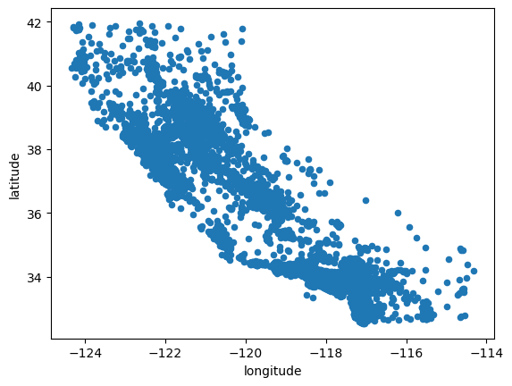

```python
housing.plot(kind="scatter", x="longitude", y="latitude") # since there is geographical information we make scatter plot to visualize the data
```

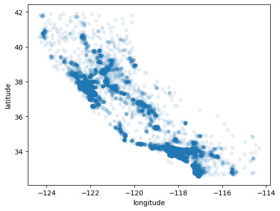

```python
# Setting the alpha option to 0.1 makes it much easier to visualize the places where there is a high density of data points.
housing.plot(kind="scatter", x="longitude", y="latitude", alpha=0.1)
```

Here we can clearly see the high density areas, namely the Bay Area and around Los Angeles and San Diego, plus a long line of fairly high density in the Central Valley, in particular around Sacramento and Fresno.

# Visualisation

```python
import seaborn as sns
```

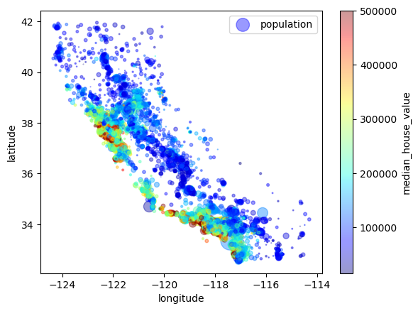

```python
housing.plot(kind="scatter", x="longitude", y="latitude", alpha=0.4,\
             s=housing["population"]/100, label="population",c="median_house_value", \
             cmap=plt.get_cmap("jet"), colorbar=True)
plt.legend()
```

On the scatterplot we can see, that the housing prices are related to the location (close to the ocean) and to the population density, but we know that the housing prices of coastal districts are not that high in Northern California, so we can't make that rule as simple as that.

It will probably be useful to use a clustering algorithm to detect the main clusters and add new features that measure the proximity to the cluster centers.

# Correlation

Since the dataset is not too large, you can easily compute the standard correlation coefficient (also called Pearson’s r) between every pair of attributes using the corr() method:

```python
corr_matrix = housing.loc[ : , housing.columns!='ocean_proximity'].corr()
#the full correlation matrix
corr_matrix
```

[output not shown]

```python
#Correlation for a single variable, let us use median_income
corr_matrix['median_income'].sort_values()
```

[output not shown]

The coefficient of the correlation ranges from 1 to -1. The closer it is to 1 the more correlated it is and vice versa. Correlations that are close to 0, means that there is no correlation, neither negative or positive. You can see that the median_income is correlated the most with the median house value. Because of that, we will generate a more detailed scatterplot below:

# Scatter Matrix

[output not shown]

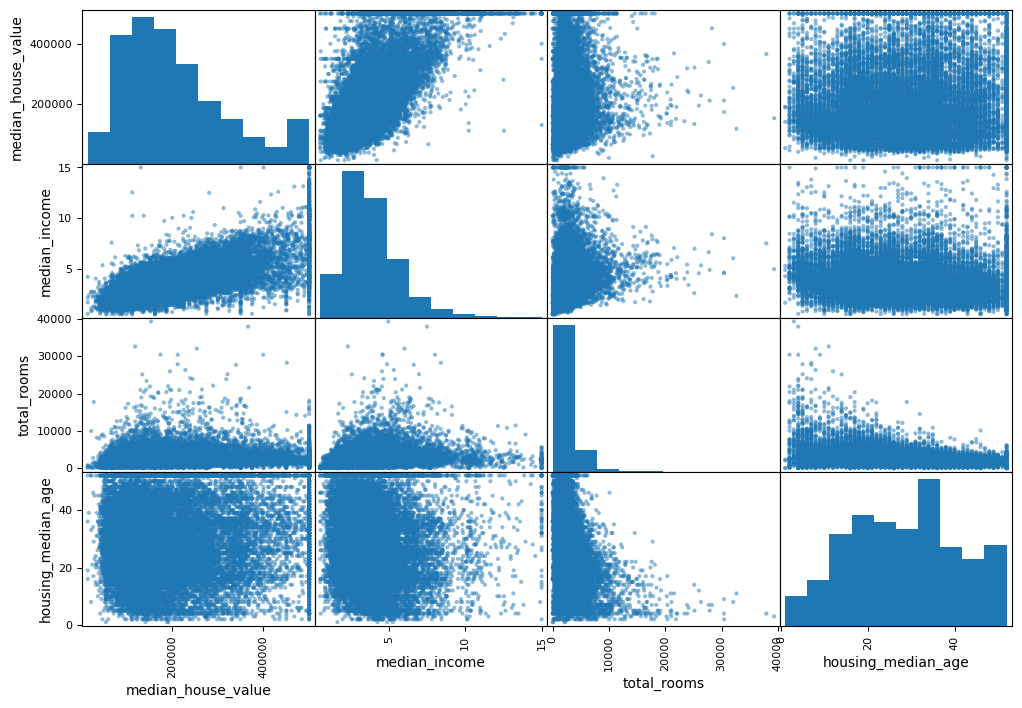

```python
from pandas.plotting import scatter_matrix
attributes=["median_house_value","median_income","total_rooms","housing_median_age"]
scatter_matrix(housing[attributes], figsize=(12, 8))
```

These graphs show the distribution of the feature variables along the main diagonal and the scatter plots show the relationship between pairs of vairables. We can even make these scatter plots separately as follows:

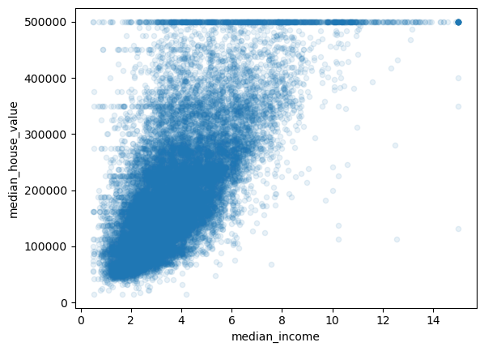

```python
housing.plot(kind="scatter", x="median_income", y="median_house_value", alpha=0.1)
```

The scatterplot reveals, that the correlation is indeed very strong because we can clearly see an upward trend and the points are not to dispersed. We can also clearly see the price-cap, we talked about earlier, at 500 000 as a horizontal line.

# Attribute Combination

Before we now actually prepare the data to fed it into the model, we should think about combinating a few attributes.

```python
housing["rooms_per_household"] = housing["total_rooms"]/housing["households"]
housing["bedrooms_per_room"] = housing["total_bedrooms"]/housing["total_rooms"]
housing["population_per_household"]=housing["population"]/housing["households"]
```

```python
corr_matrix = housing.loc[ : , housing.columns!='ocean_proximity'].corr()
corr_matrix["median_house_value"].sort_values(ascending=False)
```

```
median_house_value          1.000000
median_income               0.687151
rooms_per_household         0.146255
total_rooms                 0.135140
housing_median_age          0.114146
households                  0.064590
total_bedrooms              0.047781
population_per_household   -0.021991
population                 -0.026882
longitude                  -0.047466
latitude                   -0.142673
bedrooms_per_room          -0.259952
Name: median_house_value, dtype: float64
```

Now we see, that the bedrooms_per_room attribute is more correlated with the median house value than the total number of rooms or bedrooms. Houses with a lower bedroom/room ratio tend to be more expensive. The rooms_per_household attribute is also better than the total number of rooms in a district. Obviously the larger the house, the higher the price.

# Data Preparation

Now it is time to prepare the data so that our model can process it. We will write functions that do this instead of doing it manually.

```python
housing = strat_train_set.drop("median_house_value", axis=1) # drop labels for training set
housing_labels = strat_train_set["median_house_value"].copy()
```

We noticed earlier that the total_bedrooms attribute has some missing values. Most Machine Learning algorithms can't work with datasets that have missing values.

There are 3 ways to solve this problem:

1. You could remove the whole attribute ,2. You could get rid of the districts that contain missing values.
2. You could replace them with zeros, the median or the mean

We chose option 3 and will compute the median on the training set. Sklearn provides you with "Imputer" to do this. You first need to specify an Imputer instance, that specifies that you want to replace each attributes missing values with the median of that attribute. Because the median can only be computed on numerical attributes, we need to make a copy of the data without the ocean_proximity attribute that contains text and no numbers.

While Preparing the Data for ML we will work on the following pints:

1. Data Cleaning
2. Handling Text and Categorical Data
3. Custom Transformers
4. Feature Scaling
5. Transformation Pipelines

# DATA CLEANING

• Most Machine Learning algorithms cannot work with missing features, so let’s create a few functions to take care of them. • You noticed earlier that the total_bedrooms attribute has some missing values, so let’s fix this. You have three options: • Get rid of the corresponding districts. • Get rid of the whole attribute. • Set the values to some value (zero, the mean, the median, etc.). • You can accomplish these easily using DataFrame’s dropna(), drop(), and fillna() methods:

```python
housing.dropna(subset=["total_bedrooms"]) # option 1
housing.drop("total_bedrooms", axis=1) # option 2
median = housing["total_bedrooms"].median()
housing["total_bedrooms"].fillna(median) #option 3 #set the values to some value (like zero,mean or median)
```

[output not shown]

```python
median = housing["total_bedrooms"].median()

from sklearn.impute import SimpleImputer

imputer = SimpleImputer(strategy="median")

#Since the median can only be computed on numerical attributes, we need to create a copy of the data without the text attribute ocean_proximity:

housing_num = housing.drop('ocean_proximity', axis=1)
```

Now we can fit the Imputer instance to the training data using the "fit()" method.

```python
imputer.fit(housing_num)
```

```
SimpleImputer(strategy='median')
```

```python
imputer.statistics_
```

[output not shown]

```python
housing_num.median().values
```

[output not shown]

Now you can use this “trained” imputer to transform the training set by replacing missing values by the learned medians:

Now that we have trained the Imputer we can use it to impute values. After imputation we get the results in the form of numpy array so we have to convert it back to Pandas dataframe.

```python
X=imputer.transform(housing_num)
housing_tr=pd.DataFrame(X, columns=housing_num.columns, index = list(housing.index.values))
```

```python
housing_tr.head()
```

[output not shown]

# Handling Categorical Attributes

```python
from sklearn.preprocessing import LabelBinarizer
# label binarization, which is the process of converting categorical labels into binary (0/1) representation. This is particularly useful when dealing with categorical target variables in classification tasks.
encoder = LabelBinarizer() # to transform categorical labels into binary representation
housingCat = housing['ocean_proximity']
housingCat1hot = encoder.fit_transform(housingCat)
```

```python
housingCat1hot
#this is a numpy array
```

```
array([[0, 0, 0, 1, 0],
       [0, 0, 0, 1, 0],
       [0, 0, 0, 1, 0],
       ...,
       [0, 1, 0, 0, 0],
       [0, 1, 0, 0, 0],
       [0, 1, 0, 0, 0]])
```

# Transformation Pipelines

```python
from sklearn.base import BaseEstimator, TransformerMixin

rooms_ix, bedrooms_ix, population_ix, household_ix = 3, 4, 5, 6

class CombinedAttributesAdder(BaseEstimator, TransformerMixin):
    def __init__(self, add_bedrooms_per_room = True):
        self.add_bedrooms_per_room = add_bedrooms_per_room
    def fit(self, X, y=None):
        return self
    def transform(self, X, y=None):
        rooms_per_household = X[:, rooms_ix] / X[:, household_ix]
        population_per_household = X[:, population_ix] / X[:, household_ix]
        if self.add_bedrooms_per_room:
            bedrooms_per_room = X[:, bedrooms_ix] / X[:, rooms_ix]
            return np.c_[X, rooms_per_household, population_per_household,
                         bedrooms_per_room]
        else:
            return np.c_[X, rooms_per_household, population_per_household]

attr_adder = CombinedAttributesAdder(add_bedrooms_per_room=False)
housing_extra_attribs = attr_adder.transform(housing.values)
```

```python
from sklearn.pipeline import Pipeline
from sklearn.preprocessing import StandardScaler

num_pipeline = Pipeline([
        ('imputer', SimpleImputer(strategy="median")),# to handle the missing values with median of that column attribute
        ('attribs_adder', CombinedAttributesAdder()),
        ('std_scaler', StandardScaler()),
    ])

housing_num_tr = num_pipeline.fit_transform(housing_num)
```

```python
housing_num_tr
```

```
array([[-1.32783522,  1.05254828,  0.98214266, ...,  0.62855945,
        -0.04959654, -1.02998783],
       [-1.32284391,  1.04318455, -0.60701891, ...,  0.32704136,
        -0.09251223, -0.8888972 ],
       [-1.33282653,  1.03850269,  1.85618152, ...,  1.15562047,
        -0.02584253, -1.29168566],
       ...,
       [-0.8237132 ,  1.77823747, -0.92485123, ..., -0.09031802,
        -0.0717345 ,  0.02113407],
       [-0.87362627,  1.77823747, -0.84539315, ..., -0.04021111,
        -0.09122515,  0.09346655],
       [-0.83369581,  1.75014627, -1.00430931, ..., -0.07044252,
        -0.04368215,  0.11327519]])
```

```python
from sklearn.preprocessing import OneHotEncoder
# used to convert categorical variables into a "one-hot" or "dummy" encoded representation.
from sklearn.base import BaseEstimator, TransformerMixin

class DataFrameSelector(BaseEstimator, TransformerMixin):
    def __init__(self, attribute_names):
        self.attribute_names = attribute_names
    def fit(self, X, y=None):
        return self
    def transform(self, X):
        return X[self.attribute_names].values
```

```python
num_attribs = list(housing_num)
cat_attribs = ["ocean_proximity"]

num_pipeline = Pipeline([
        ('selector', DataFrameSelector(num_attribs)),
        ('imputer', SimpleImputer(strategy="median")),
        ('attribs_adder', CombinedAttributesAdder()),
        ('std_scaler', StandardScaler()),
    ])

cat_pipeline = Pipeline([
        ('selector', DataFrameSelector(cat_attribs)),
        ('one_hot_encoder', OneHotEncoder(sparse=False)),
    ])
```

```python
# Now we combine the two pipelines
from sklearn.pipeline import FeatureUnion

full_pipeline = FeatureUnion(transformer_list=[
        ("num_pipeline", num_pipeline),
        ("cat_pipeline", cat_pipeline),
    ])
```

```python
housing_prepared = full_pipeline.fit_transform(housing)
housing_prepared
```

```
array([[-0.94135046,  1.34743822,  0.02756357, ...,  0.        ,
         0.        ,  0.        ],
       [ 1.17178212, -1.19243966, -1.72201763, ...,  0.        ,
         0.        ,  1.        ],
       [ 0.26758118, -0.1259716 ,  1.22045984, ...,  0.        ,
         0.        ,  0.        ],
       ...,
       [-1.5707942 ,  1.31001828,  1.53856552, ...,  0.        ,
         0.        ,  0.        ],
       [-1.56080303,  1.2492109 , -1.1653327 , ...,  0.        ,
         0.        ,  0.        ],
       [-1.28105026,  2.02567448, -0.13148926, ...,  0.        ,
         0.        ,  0.        ]])
```

# Train Models

First, let's test whether a Linear Regression model gives us a satisfying result:

```python
from sklearn.linear_model import LinearRegression

lin_reg = LinearRegression()
lin_reg.fit(housing_prepared, housing_labels)
```

```
LinearRegression()
```

```python
ex = housing.iloc[:5]
ex_labels = housing_labels.iloc[:5]
ex_data_prepared = full_pipeline.transform(ex)

print("Predictions:", lin_reg.predict(ex_data_prepared))
print("Labels:",list(ex_labels))
```

```
Predictions: [ 85657.90192014 305492.60737488 152056.46122456 186095.70946094
 244550.67966089]
Labels: [72100.0, 279600.0, 82700.0, 112500.0, 238300.0]
```

• Let’s measure this regression model’s RMSE on the whole training set using Scikit-Learn’s mean_squared_error function:

Let's use [RMSE (Root Mean Squared Error)](http://www.statisticshowto.com/rmse/) to judge the quality of our predictions:

```python
from sklearn.metrics import mean_squared_error

housing_predictions = lin_reg.predict(housing_prepared)
lin_mse = mean_squared_error(housing_labels, housing_predictions)
lin_rmse = np.sqrt(lin_mse)
lin_rmse
```

```
68627.87390018745
```

okay ,This is better than nothing but clearly not a great score. Since most districts median_housing_values range between 120,000 and 265,000 dollar, a prediction error of $68,627 is not very satisfying and also an example of a model underfitting the data. This either means that the features do not provide enough information to make proper predictions, or that the model is just not powerful enough.

The main ways to fix underfitting are:

1.) feed the model with better features 2.) select a more powerful model 3.) reduce the constraints on the model

First let's try out a more powerful model since we just only tested one.

Let's use a DecisionTreeRegressor, which can find complex nonlinear relationships in the data:

```python
from sklearn.tree import DecisionTreeRegressor

tree_reg = DecisionTreeRegressor(random_state=42)
tree_reg.fit(housing_prepared, housing_labels)
```

```
DecisionTreeRegressor(random_state=42)
```

```python
housing_predictions = tree_reg.predict(housing_prepared)
tree_mse = mean_squared_error(housing_labels, housing_predictions)
tree_rmse = np.sqrt(tree_mse)
tree_rmse
```

```
0.0
```

This gives you no error at all, which means that we strongly overfitted our data. How can we be sure ? As we allready discussed earlier, you don't want to use the test set until you are confident about your model. But how can we test how our model performs if we can't use the test data ? One way to do this is using

**K-Fold Cross-Validation**, which uses part of the training set for training and a part for validation. The following code randomly splits the training set into 10 subset called **folds**. Then it trains and evaluates the Decision tree model 10 times, picking a different fold for evaluation every time and training on the other 9 folds

The result is an array containing the 10 evaluation scores:

```python
from sklearn.model_selection import cross_val_score

scores = cross_val_score(tree_reg, housing_prepared, housing_labels,
                         scoring="neg_mean_squared_error", cv=10)
tree_rmse_scores = np.sqrt(-scores)
```

Let's look at the result:

```python
def display_scores(scores):
    print("Scores:", scores)
    print("Mean:", scores.mean())
    print("Standard deviation:", scores.std())

display_scores(tree_rmse_scores)
```

```
Scores: [72831.45749112 69973.18438322 69528.56551415 72517.78229792
 69145.50006909 79094.74123727 68960.045444   73344.50225684
 69826.02473916 71077.09753998]
Mean: 71629.89009727491
Standard deviation: 2914.035468468928
```

• Now the Decision Tree doesn’t look as good as it did earlier. In fact, it seems to perform worse than the Linear Regression model!

• Notice that cross-validation allows you to get not only an estimate of the performance of your model, but also a measure of how precise this estimate is (i.e., its standard deviation)

Random Forests work by training many Decision Trees on random subsets of the features, then averaging out their predictions.

```python
from sklearn.ensemble import RandomForestRegressor

forest_reg = RandomForestRegressor(random_state=42)
forest_reg.fit(housing_prepared, housing_labels)
```

```
RandomForestRegressor(random_state=42)
```

```python
housing_pred=forest_reg.predict(housing_prepared)
forest_mse=mean_squared_error(housing_labels, housing_pred)
forest_rmse=np.sqrt(forest_mse)
forest_rmse
```

```
18650.698705770003
```

```python
forest_scores = cross_val_score(forest_reg, housing_prepared, housing_labels,\
                                scoring="neg_mean_squared_error", cv=10)
forest_rmse= np.sqrt(-forest_scores)
display_scores(forest_rmse)
```

[output not shown]

# Fine Tuning Of Parameters

You now need to fine-tune them. Let’s look at a few ways you can do that:

• Grid Search

• Randomized Search

• Ensemble Methods

• One way to do that would be to fiddle with the hyperparameters manually, until you find a great combination of hyperparameter values.

• This would be very tedious work, and you may not have time to explore many combinations.

• Instead you should get Scikit-Learn’s GridSearchCV to search for you.

For example, the following code searches for the best combination of hyperparameter values for the RandomForestRegressor:

```python
from sklearn.model_selection import GridSearchCV

param_grid = [
    {'n_estimators': [3, 10, 30], 'max_features': [2, 4, 6, 8]},
    {'bootstrap': [False], 'n_estimators': [3, 10], 'max_features': [2, 3, 4]},
  ]

forest_reg = RandomForestRegressor(random_state=42)
grid_search = GridSearchCV(forest_reg, param_grid, cv=5,
                           scoring='neg_mean_squared_error')
grid_search.fit(housing_prepared, housing_labels)
```

```python
grid_search.best_params_
```

[output not shown]

# Evaluation

Now that we have our best parameter values, we can fit a final model using these.

```python
final_model = grid_search.best_estimator_
X_test = strat_test_set.drop("median_house_value", axis=1)
y_test = strat_test_set["median_house_value"].copy()

X_test_prepared = full_pipeline.transform(X_test)
final_predictions = final_model.predict(X_test_prepared)

final_mse = mean_squared_error(y_test, final_predictions)
final_rmse = np.sqrt(final_mse)
```

```python
final_rmse
```

[output not shown]

# EVALUATE YOUR SYSTEM ON THE TEST SET

• The performance will usually be slightly worse than what you measured using crossvalidation if you did a lot of hyperparameter tuning (because your system ends up fine-tuned to perform well on the validation data, and will likely not perform as well on unknown datasets).

• It is not the case in this example, but when this happens you must resist the temptation to tweak the hyperparameters to make the numbers look good on the test set; the improvements would be unlikely to generalize to new data.

• Now comes the project prelaunch phase: you need to present your solution (highlighting what you have learned, what worked and what did not, what assumptions were made, and what your system’s limitations are), document everything, and create nice presentations with clear visualizations and easy-to-remember statements (e.g., “the median income is the number one predictor of housing prices”).

# LAUNCH, MONITOR, AND MAINTAIN YOUR SYSTEM

• Perfect, you got approval to launch! You need to get your solution ready for production, in particular by plugging the production input data sources into your system and writing tests.

• You also need to write monitoring code to check your system’s live performance at regular intervals and trigger alerts when it drops.

• This is important to catch not only sudden breakage, but also performance degradation.

• This is quite common because models tend to “rot” as data evolves over time, unless the models are regularly trained on fresh data.

• Evaluating your system’s performance will require sampling the system’s predictions and evaluating them.

• This will generally require a human analysis. These analysts may be field experts, or workers on a crowdsourcing platform (such as Amazon Mechanical Turk or CrowdFlower).

• Either way, you need to plug the human evaluation pipeline into your system.